# Real-World Machine Learning

Chapter 4

Paul Adamson

December 25, 2016

This notebook contains R code to accompany Chapter 4 of the book [“Real-World Machine Learning”](https://www.manning.com/books/real-world-machine-learning), by Henrik Brink, Joseph W. Richards, and Mark Fetherolf.  
The code was contributed by [Paul Adamson](http://github.com/padamson).

*NOTE: working directory should be set to this file’s location.*

*NOTE: depending on your machine, you may need to adjust the parameter in the call to `makeCluster()` in the code to generate Figure 4.19*

## Figure 4.9 The first five rows of the Titanic Passengers dataset

As in Chapter 3, we are going to be interested in predicting survival, so again, it is useful to specify the `Survived` variable to be of type `factor`. For visualizing the data, it is also useful to use the `revalue` function to specify the `no` and `yes` levels for the `factor` variable. The `kable` function is built into the `knitr` package.

```r
titanic <- read.csv("../data/titanic.csv",
                    colClasses = c(
                      Survived = "factor",
                      Name = "character",
                      Ticket = "character",
                      Cabin = "character"))
titanic$Survived <- revalue(titanic$Survived, c("0"="no", "1"="yes"))
kable(head(titanic, 5), digits=2)
```

| PassengerId | Survived | Pclass | Name | Sex | Age | SibSp | Parch | Ticket | Fare | Cabin | Embarked |
| --- | --- | --- | --- | --- | --- | --- | --- | --- | --- | --- | --- |
| 1 | no | 3 | Braund, Mr. Owen Harris | male | 22 | 1 | 0 | A/5 21171 | 7.25 |  | S |
| 2 | yes | 1 | Cumings, Mrs. John Bradley (Florence Briggs Thayer) | female | 38 | 1 | 0 | PC 17599 | 71.28 | C85 | C |
| 3 | yes | 3 | Heikkinen, Miss. Laina | female | 26 | 0 | 0 | STON/O2. 3101282 | 7.92 |  | S |
| 4 | yes | 1 | Futrelle, Mrs. Jacques Heath (Lily May Peel) | female | 35 | 1 | 0 | 113803 | 53.10 | C123 | S |
| 5 | no | 3 | Allen, Mr. William Henry | male | 35 | 0 | 0 | 373450 | 8.05 |  | S |

## Figure 4.10 Splitting the full dataset into training and testing sets

Here, we follow the same process used for Figure 3.6 to process the data and prepare it for our model. First, we get rid of the variables that we do not want in our model. (`Cabin` might actually be useful, but it’s not used here.) Then we use `is.na` to set missing age values to -1. The `mutate` and `select` functions make it easy to take square root of the `Fare` variable and then drop it from the dataset. We then drop rows with missing `Embarked` data and remove the unused level `""`. Finally, we convert `factor` variables to dummy variables using the `dummyVars` function in the `caret` package. To avoid perfect collinearity (a.k.a. the dummy variable trap), we set the `fullRank` parameter to `TRUE`. `Survived.yes` is then converted back to a `factor` variable, and its levels are changed back to ‘yes’ and ‘no’ again (otherwise the `train` function in `caret` will complain later about invalid R variable names).

We then make a 80%/20% train/test split using the `Survived` factor variable in the `createDataPartition` function to preserve the overall class distribution of the data.

```r
titanicTidy <- subset(titanic, select = -c(PassengerId, Name, Ticket, Cabin))

titanicTidy$Age[is.na(titanicTidy$Age)] <- -1

titanicTidy <- titanicTidy %>%
  mutate(sqrtFare = sqrt(Fare)) %>%
  select(-Fare)

titanicTidy <- titanicTidy %>%
  filter(!(Embarked=="")) %>%
  droplevels

dummies <- dummyVars(" ~ .", data = titanicTidy, fullRank = TRUE)
titanicTidyNumeric <- data.frame(predict(dummies, newdata = titanicTidy))

titanicTidyNumeric$Survived.yes <- factor(titanicTidyNumeric$Survived.yes)
titanicTidyNumeric$Survived.yes <-
  revalue(titanicTidyNumeric$Survived.yes, c("0"="no", "1"="yes"))

trainIndex <- createDataPartition(titanicTidyNumeric$Survived.yes, p = .8,
                                  list = FALSE,
                                  times = 1)

titanicTrain <- titanicTidyNumeric[ trainIndex,]
titanicTest  <- titanicTidyNumeric[-trainIndex,]

kable(head(titanicTidyNumeric, 8), digits=2, caption = "Full dataset")
```

Full dataset

| Survived.yes | Pclass | Sex.male | Age | SibSp | Parch | Embarked.Q | Embarked.S | sqrtFare |
| --- | --- | --- | --- | --- | --- | --- | --- | --- |
| no | 3 | 1 | 22 | 1 | 0 | 0 | 1 | 2.69 |
| yes | 1 | 0 | 38 | 1 | 0 | 0 | 0 | 8.44 |
| yes | 3 | 0 | 26 | 0 | 0 | 0 | 1 | 2.82 |
| yes | 1 | 0 | 35 | 1 | 0 | 0 | 1 | 7.29 |
| no | 3 | 1 | 35 | 0 | 0 | 0 | 1 | 2.84 |
| no | 3 | 1 | -1 | 0 | 0 | 1 | 0 | 2.91 |
| no | 1 | 1 | 54 | 0 | 0 | 0 | 1 | 7.20 |
| no | 3 | 1 | 2 | 3 | 1 | 0 | 1 | 4.59 |

```r
kable(head(titanicTrain, 5), digits=2,
      caption = "Training set: used only for building the model")
```

Training set: used only for building the model

|  | Survived.yes | Pclass | Sex.male | Age | SibSp | Parch | Embarked.Q | Embarked.S | sqrtFare |
| --- | --- | --- | --- | --- | --- | --- | --- | --- | --- |
| 1 | no | 3 | 1 | 22 | 1 | 0 | 0 | 1 | 2.69 |
| 2 | yes | 1 | 0 | 38 | 1 | 0 | 0 | 0 | 8.44 |
| 4 | yes | 1 | 0 | 35 | 1 | 0 | 0 | 1 | 7.29 |
| 6 | no | 3 | 1 | -1 | 0 | 0 | 1 | 0 | 2.91 |
| 8 | no | 3 | 1 | 2 | 3 | 1 | 0 | 1 | 4.59 |

```r
kable(head(titanicTest, 3), digits=2,
      caption = "Testing set: used only for evaluating model")
```

Testing set: used only for evaluating model

|  | Survived.yes | Pclass | Sex.male | Age | SibSp | Parch | Embarked.Q | Embarked.S | sqrtFare |
| --- | --- | --- | --- | --- | --- | --- | --- | --- | --- |
| 3 | yes | 3 | 0 | 26 | 0 | 0 | 0 | 1 | 2.82 |
| 5 | no | 3 | 1 | 35 | 0 | 0 | 0 | 1 | 2.84 |
| 7 | no | 1 | 1 | 54 | 0 | 0 | 0 | 1 | 7.20 |

## Figure 4.11 Comparing the testing set predictions with the actual values gives you the accuracy of the model.

```r
objControl <- trainControl(method='cv', number=3,
                           returnResamp='none',
                           summaryFunction = twoClassSummary,
                           classProbs = TRUE)
titanic.gbm <- train(Survived.yes~.,data=titanicTrain, method='gbm',
                     trControl=objControl,
                     metric = "ROC",
                     preProc = c("center", "scale"))
```

```r
titanic.gbm.pred <- predict(titanic.gbm,newdata=titanicTest)

figure4.11.df <- data.frame(head(titanicTest$Survived.yes),
                            head(titanic.gbm.pred))
kable(figure4.11.df,
      col.names = c("Test set labels", "Predictions"))
```

| Test set labels | Predictions |
| --- | --- |
| yes | no |
| no | no |
| no | no |
| yes | no |
| yes | yes |
| no | no |

## Figure 4.13 Organizing the class-wise accuracy into a confusion matrix

```r
titanic.gbm.cm <- confusionMatrix(titanic.gbm.pred,titanicTest$Survived.yes)
titanic.gbm.cm
```

```
## Confusion Matrix and Statistics
##
##           Reference
## Prediction no yes
##        no  98  31
##        yes 11  37
##
##                Accuracy : 0.7627
##                  95% CI : (0.6931, 0.8233)
##     No Information Rate : 0.6158
##     P-Value [Acc > NIR] : 2.393e-05
##
##                   Kappa : 0.4692
##  Mcnemar's Test P-Value : 0.00337
##
##             Sensitivity : 0.8991
##             Specificity : 0.5441
##          Pos Pred Value : 0.7597
##          Neg Pred Value : 0.7708
##              Prevalence : 0.6158
##          Detection Rate : 0.5537
##    Detection Prevalence : 0.7288
##       Balanced Accuracy : 0.7216
##
##        'Positive' Class : no
##
```

## Figure 4.15 A subset of probabilistic predictions from the Titanic test set. After sorting the full table by decreasing survival probability, you can set a threshold and consider all rows above this threshold as survived. Note that the indices are maintained so you know which original row the instance refers to.

```r
titanic.gbm.pred.prob <- predict(object=titanic.gbm,
                                 titanicTest, type='prob')
kable(titanic.gbm.pred.prob[15:19,],col.names = c("Died","Survived"))
```

|  | Died | Survived |
| --- | --- | --- |
| 15 | 0.8774734 | 0.1225266 |
| 16 | 0.8842786 | 0.1157214 |
| 17 | 0.8166056 | 0.1833944 |
| 18 | 0.8774734 | 0.1225266 |
| 19 | 0.8989089 | 0.1010911 |

```r
titanic.ordered <- titanic.gbm.pred.prob[order(-titanic.gbm.pred.prob$yes),]
kable(titanic.ordered[titanic.ordered$yes > 0.68 & titanic.ordered$yes < 0.73,])
```

|  | no | yes |
| --- | --- | --- |
| 137 | 0.2851770 | 0.7148230 |
| 25 | 0.3000107 | 0.6999893 |
| 63 | 0.3190296 | 0.6809704 |

## Listing 4.3 The ROC curve

```r
# Returns the false-positive and true-positive rates at nPoints thresholds for
# the given true and predicted labels
# trueLabels: 0=FALSE; 1=TRUE
rocCurve <- function(trueLabels, predictedProbs, nPoints=100, posClass=1){
  # Allocates the threshold and ROC lists
  thr <- seq(0,1,length=nPoints)
  tpr <- numeric(nPoints)
  fpr <- numeric(nPoints)

  # Precalculates values for the positive and negative cases, used in the loop
  pos <- trueLabels == posClass
  neg <- !pos
  nPos <- sum(pos, na.rm=TRUE)
  nNeg <- sum(neg, na.rm=TRUE)

  # For each threshold, calculates the rate of true and false positives
  for (i in 1:length(thr)) {
    t <- thr[i]
    meetOrExceedThreshold <- predictedProbs >= t
    tpr[i] <-  sum((meetOrExceedThreshold & pos), na.rm=TRUE) / nPos
    fpr[i] <-  sum((meetOrExceedThreshold & neg), na.rm=TRUE) / nNeg
  }

  # Create data frame without duplicated fpr's to return
  duplicatedFPRs <- duplicated(fpr)
  df <- data.frame(fpr=fpr[!duplicatedFPRs],tpr=tpr[!duplicatedFPRs],thr=thr[!duplicatedFPRs])

  return(df)
}
```

## Figure 4.16 The ROC curve defined by calculating the confusion matrix and ROC metrics at 100 threshold points from 0 to 1. By convention, you plot the false-positive rate on the x-axis and the true-positive rate on the y-axis.

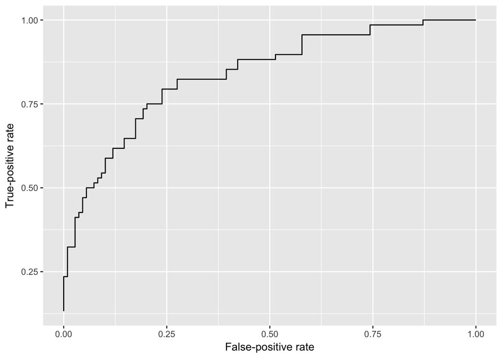

```r
df<-rocCurve(revalue(titanicTest$Survived.yes, c("no" = 0, "yes" = 1)),
             titanic.gbm.pred.prob$yes)
ggplot(df,aes(x=fpr,y=tpr)) +
  geom_step(direction="vh") +
  labs(x = "False-positive rate",
       y = "True-positive rate")
```

## Listing 4.4 The area under the ROC curve

```r
auc <- function(trueLabels, predictedProbs, nPoints=100, posClass=1){
  auc <- 0
  df <- rocCurve(trueLabels = trueLabels,
                 predictedProbs = predictedProbs,
                 nPoints = nPoints,
                 posClass = posClass)

  for (i in 2:length(df$fpr)) {
    auc <- auc + 0.5 * (df$fpr[i-1] - df$fpr[i]) * (df$tpr[i-1] + df$tpr[i])
  }

  return(auc)
}
```

## Bonus. Relative influence of variables in model.

We can call the `summary` function on our model to get a data frame of variables (`var`) and their relative influence (`rel.inf`) in the model. Before plotting the data, we reorder by the `rel.inf` variable.

```r
gbmSummary <- summary(titanic.gbm)
```

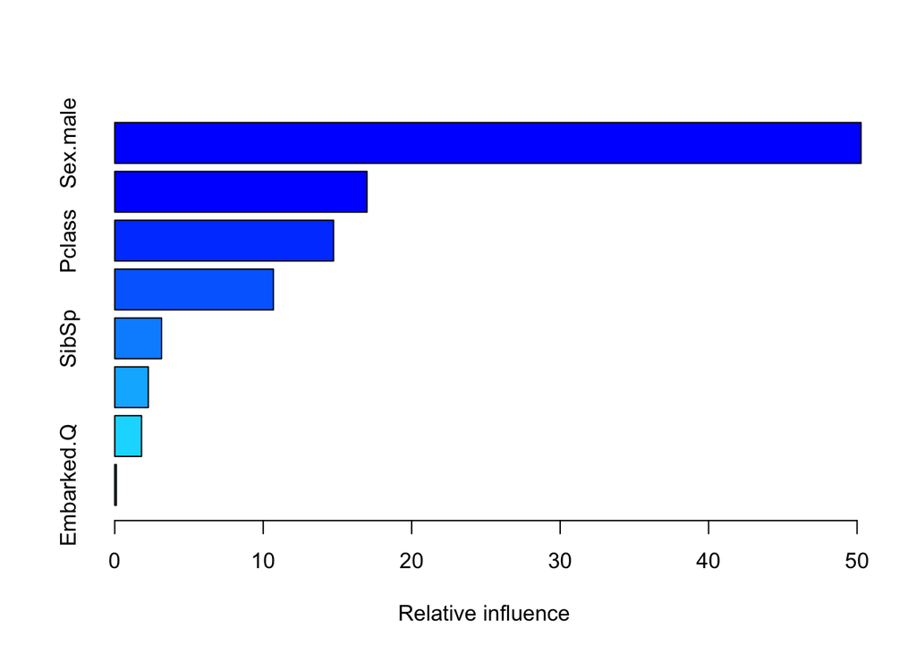

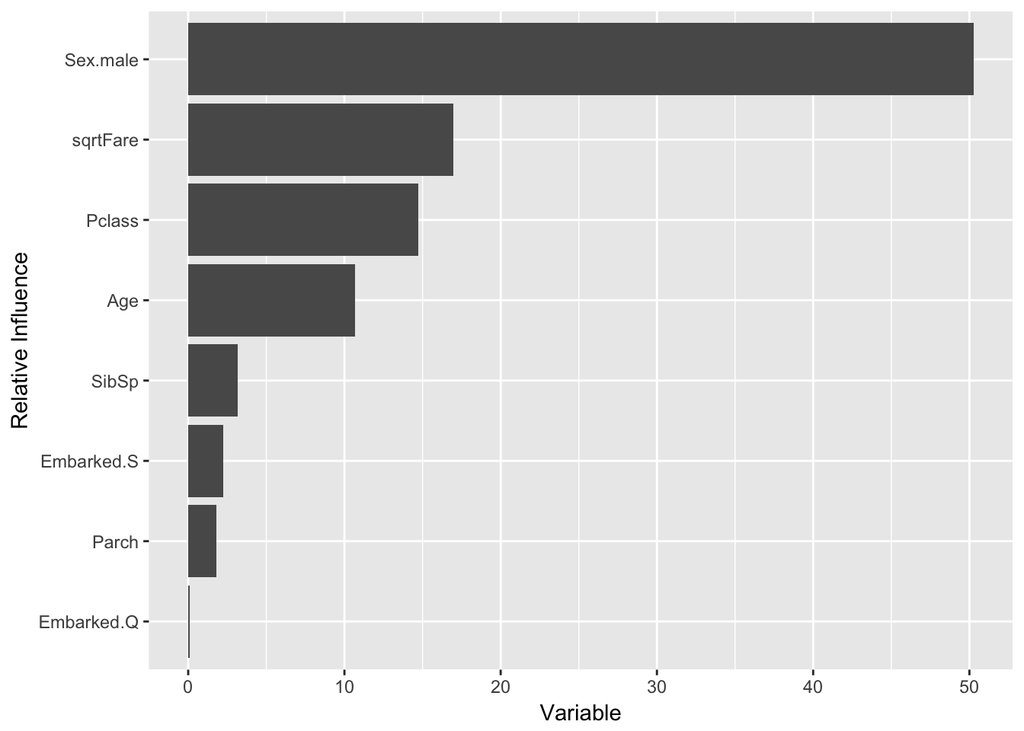

```r
gbmSummary <- transform(gbmSummary,
                        var = reorder(var,rel.inf))
ggplot(data=gbmSummary, aes(var, rel.inf)) +
  geom_bar(stat="identity") +
  coord_flip() +
  labs(x="Relative Influence",
       y="Variable")
```

## Figure 4.18 Handwritten digits in the MNIST dataset

Thanks to [Longhow Lam](https://longhowlam.wordpress.com/2015/11/25/a-little-h2o-deeplearning-experiment-on-the-mnist-data-set/) for posting the code used in the `displayMnistSamples` function that display’s digits from the MNIST dataset.

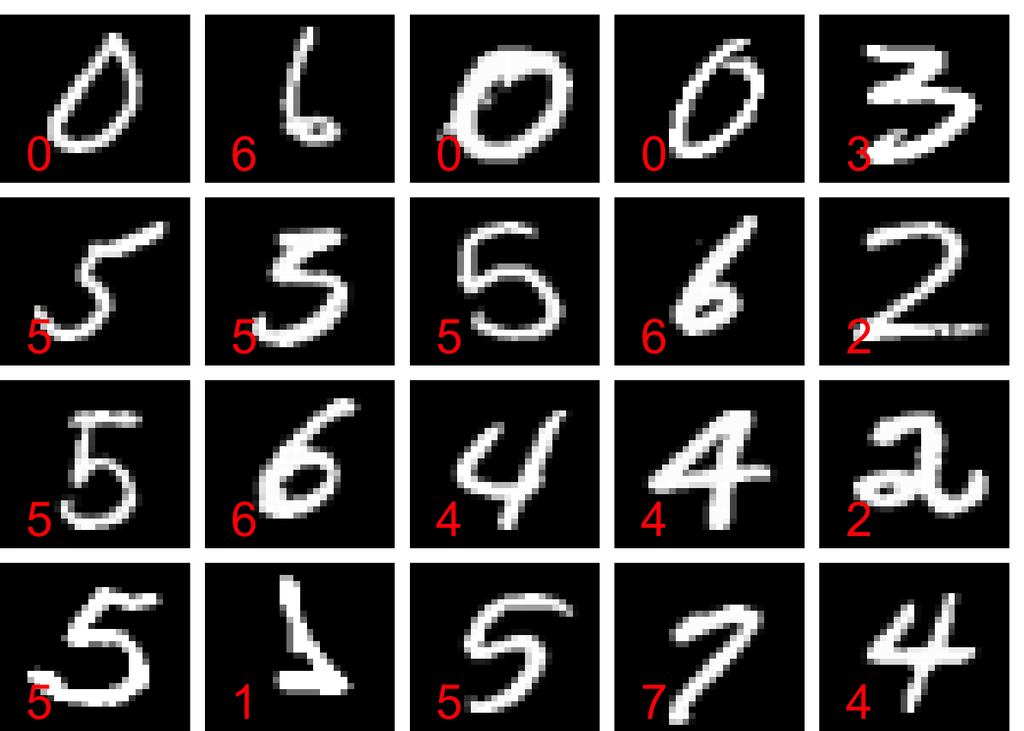

```r
mnist <- read.csv("../data/mnist_small.csv",
                  colClasses = c(label = "factor"))
displayMnistSamples <- function(x) {
  for(i in x){
  y = as.matrix(mnist[i, 2:785])
  dim(y) = c(28, 28)
  image( y[,nrow(y):1], axes = FALSE, col = gray(0:255 / 255))
  text( 0.2, 0, mnist[i,1], cex = 3, col = 2, pos = c(3,4))
  }
}
par( mfrow = c(4,5), mai = c(0,0,0.1,0.1))
displayMnistSamples(sample(1:length(mnist),20))
```

```r
levels(mnist$label) <- make.names(levels(mnist$label))
```

## Figure 4.19 The confusion matrix for the 10-class MNIST handwritten digit classification problem

```r
trainIndex <- createDataPartition(mnist$label, p = .8,
                                  list = FALSE,
                                  times = 1)

mnistTrain <- mnist[ trainIndex,]
mnistTest  <- mnist[-trainIndex,]

cl = makeCluster(4)
registerDoParallel(cl)

str(mnistTrain$label)
```

```
##  Factor w/ 10 levels "X0","X1","X2",..: 2 2 5 1 1 8 6 9 10 2 ...
```

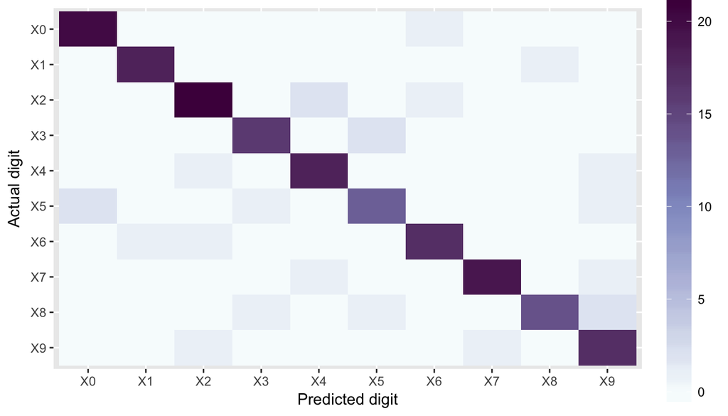

```r
myTrainingControl <- trainControl(savePredictions = TRUE,
                              classProbs = TRUE,
                              verboseIter = FALSE)

mnist.rf <- train(label~., data=mnistTrain, method='rf',
                  ntree = 50,
                  trControl = myTrainingControl,
                  probability=TRUE, allowParallel=TRUE)

mnist.rf.pred = predict(mnist.rf,newdata=mnistTest)

confusion.matrix <- confusionMatrix(mnist.rf.pred,mnistTest$label)

confusionDF <- data.frame(confusion.matrix$table)

confusionDF$Reference = with(confusionDF,
                             factor(Reference, levels = rev(levels(Reference))))

jBuPuFun <- colorRampPalette(brewer.pal(n = 9, "BuPu"))
paletteSize <- 256
jBuPuPalette <- jBuPuFun(paletteSize)

confusionPlot <- ggplot(
  confusionDF, aes(x = Prediction, y = Reference, fill = Freq)) +
  #theme(axis.text.x = element_text(angle = 0, hjust = 1, vjust = 0.5)) +
  geom_tile() +
  labs(x = "Predicted digit", y = "Actual digit") +
  scale_fill_gradient2(
    low = jBuPuPalette[1],
    mid = jBuPuPalette[paletteSize/2],
    high = jBuPuPalette[paletteSize],
    midpoint = (max(confusionDF$Freq) + min(confusionDF$Freq)) / 2,
    name = "") +
  theme(legend.key.height = unit(2, "cm"))
confusionPlot
```

## Figure 4.20 The ROC curves for each class of the MNIST 10-class classifier

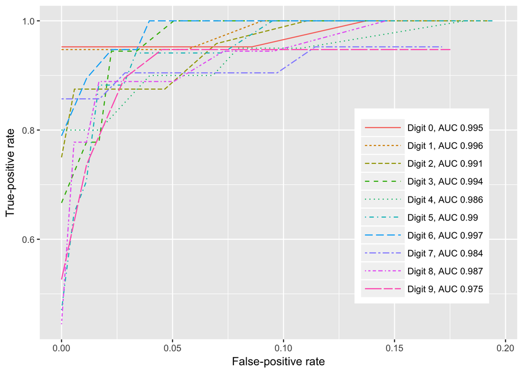

```r
rocDF<-NULL
aucDF<-NULL
mnist.rf.pred.prob <- predict(object=mnist.rf,
                              mnistTest, type='prob')
for (i in 0:9){
  digitLabel = paste0("X",i)
  trueLabels <- as.numeric(mnistTest$label==digitLabel)
  predictedProbs <- mnist.rf.pred.prob[[digitLabel]]
  rocDF <- rbind(rocDF,
                 data.frame(rocCurve(trueLabels = trueLabels, predictedProbs = predictedProbs),digit=i))
  aucDF <- rbind(aucDF,
                 data.frame(auc=auc(trueLabels = trueLabels, predictedProbs = predictedProbs),digit=i))
}
rocDF[,'digit'] <- as.factor(rocDF[,'digit'])
labelVector <- c(paste0("Digit ",0:9,", AUC ",round(aucDF$auc,3)))
ggplot(rocDF[rocDF$fpr<0.2,],aes(x=fpr,y=tpr, linetype=digit, colour=digit)) +
  geom_line() +
  labs(x = "False-positive rate",
       y = "True-positive rate") +
  scale_linetype_discrete(name=NULL,
                          labels=labelVector,
                          guide = guide_legend(keywidth = 3)) +
  scale_colour_discrete(name=NULL,
                        labels=labelVector,
                        guide = guide_legend(keywidth = 3)) +
  theme(legend.position=c(.8, .40))
```

## Figure 4.21 A subset of the Auto MPG dataset

```r
auto <- read.csv("../data/auto-mpg.csv",
                 colClasses = c(
                      origin = "factor"))

auto$origin <- revalue(auto$origin,
                       c("1\t"="USA", "2\t"="Europe", "3\t"="Asia"))

kable(head(auto,5))
```

| mpg | cylinders | displacement | horsepower | weight | acceleration | modelyear | origin |
| --- | --- | --- | --- | --- | --- | --- | --- |
| 18 | 8 | 307 | 130 | 3504 | 12.0 | 70 | USA |
| 15 | 8 | 350 | 165 | 3693 | 11.5 | 70 | USA |
| 18 | 8 | 318 | 150 | 3436 | 11.0 | 70 | USA |
| 16 | 8 | 304 | 150 | 3433 | 12.0 | 70 | USA |
| 17 | 8 | 302 | 140 | 3449 | 10.5 | 70 | USA |

## Figure 4.22 Scatter plot of the predicted MPG versus actual values from the testing set. The diagonal line shows the optimal model.

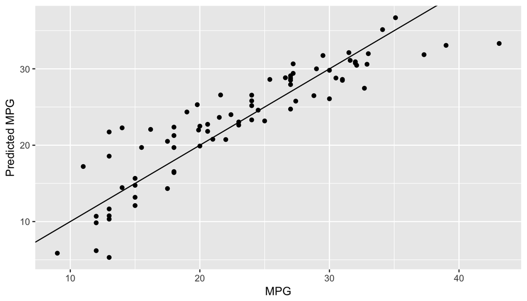

```r
dummies <- dummyVars(" ~ .", data = auto, fullRank = TRUE)
autoNumeric <- data.frame(predict(dummies, newdata = auto))

trainIndex <- createDataPartition(autoNumeric$mpg, p = .8,
                                  list = FALSE,
                                  times = 1)

autoTrain <- autoNumeric[ trainIndex,]
autoTest  <- autoNumeric[-trainIndex,]

ctrl <- trainControl(method = "repeatedcv", number = 10, savePredictions = TRUE)

auto.glm <- train(mpg ~.,
                 data=autoTrain,
                 method="glm",
                 trControl = ctrl,
                 tuneLength = 5)

auto.glm.Pred <- predict(auto.glm, newdata=autoTest)

ggplot(autoTest, aes(x=mpg, y=auto.glm.Pred)) +
  geom_point() +
  geom_abline(slope = 1, intercept = 0) +
  labs(x="MPG", y="Predicted MPG")
```

## Listing 4.5 The root-mean-square error

```r
rmse <- function(trueValues, predictedValues){
  return(sqrt(sum((trueValues - predictedValues)**2)/length(trueValues)))
}
rmse(autoTest$mpg, auto.glm.Pred)
```

```
## [1] 3.378211
```

## Listing 4.6 The R-squared calculation

```r
r2 <- function(trueValues, predictedValues) {
  meanTrueValues <- mean(trueValues)
  return( 1.0 - (sum((trueValues - predictedValues)**2) / sum((trueValues - meanTrueValues)**2) ))
}
r2(autoTest$mpg, auto.glm.Pred)
```

```
## [1] 0.8029198
```

## Figure 4.24 The residual plot from predictions on the MPG dataset.

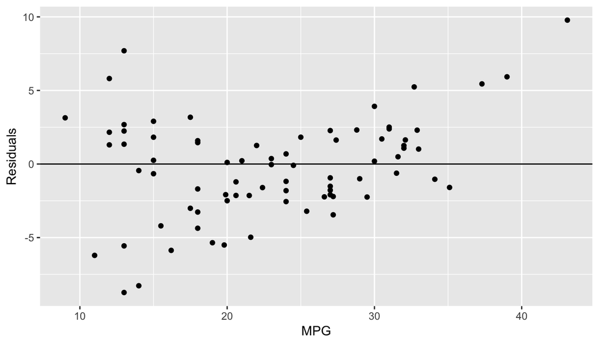

```r
autoTest$residuals <- autoTest$mpg - auto.glm.Pred

ggplot(data=autoTest, aes(x=mpg, y=residuals)) +
  geom_point() +
  geom_abline(slope = 0, intercept = 0) +
  labs(x="MPG", y="Residuals")
```

## (Substitute for Figure 4.25) Tile plots for Support Vector Machine (SVM) tuning parameter grid search

The `getModelInfo` function in the `caret` package can be used to find the available model parameters. By setting `summaryFunction = twoClassSummary` in `trainControl`, we request `ROC` to be used to select the optimal model using the largest value.

```r
svmRadialModelInfo <- getModelInfo("svmRadial")
svmRadialModelInfo$svmRadial$parameters
```

```
##   parameter   class label
## 1     sigma numeric Sigma
## 2         C numeric  Cost
```

```r
svmGrid <- expand.grid(sigma = c(0.0001,0.001,0.01,0.1),
                       C = seq(0.1,2.1,by=0.5))

fitControl <- trainControl(method = "repeatedcv",
                           number = 10,
                           savePredictions = TRUE,
                           summaryFunction=twoClassSummary,
                           classProbs=TRUE)

svmFit <- train(Survived.yes ~ ., data = titanicTrain,
                method = "svmRadial",
                trControl = fitControl,
                verbose = FALSE,
                tuneGrid = svmGrid)
```

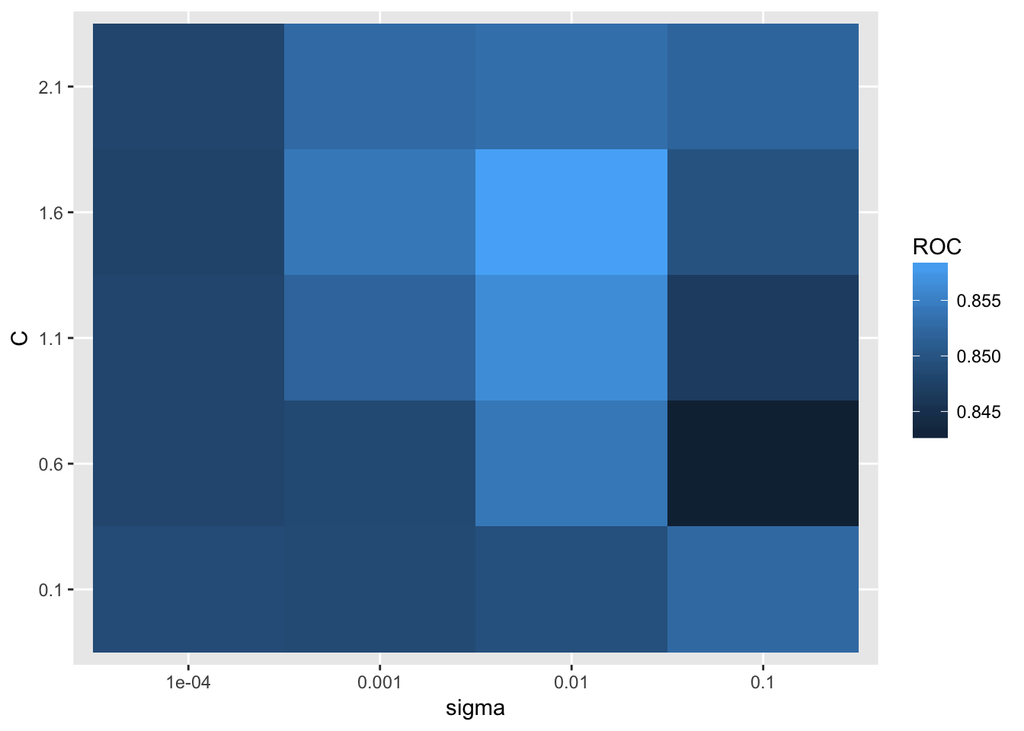

```r
svmFitDF <- data.frame(sigma = as.factor(svmFit$results$sigma),
                       C = as.factor(svmFit$results$C),
                       ROC = svmFit$results$ROC)

ggplot(svmFitDF, aes(x=sigma, y=C)) +
  geom_tile(aes(fill=ROC))
```

```r
svmFit$bestTune
```

```
##    sigma   C
## 14  0.01 1.6
```

```r
svmGrid <- expand.grid(sigma = c(5:1 %o% 10^(-3:-1)),
                       C = seq(0.1,2.1,by=0.25))

fitControl <- trainControl(method = "repeatedcv",
                           number = 10,
                           savePredictions = TRUE,
                           summaryFunction=twoClassSummary,
                           classProbs=TRUE)

svmFit <- train(Survived.yes ~ ., data = titanicTrain,
                method = "svmRadial",
                trControl = fitControl,
                verbose = FALSE,
                tuneGrid = svmGrid)
```

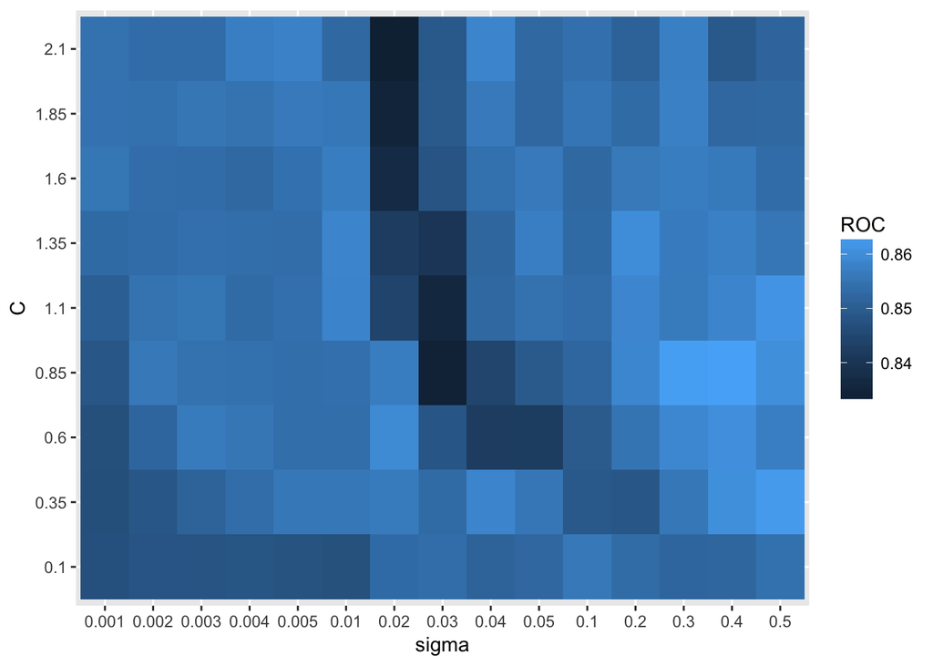

```r
svmFitDF <- data.frame(sigma = as.factor(svmFit$results$sigma),
                       C = as.factor(svmFit$results$C),
                       ROC = svmFit$results$ROC)

ggplot(svmFitDF, aes(x=sigma, y=C)) +
  geom_tile(aes(fill=ROC))
```

```r
svmFit$bestTune
```

```
##     sigma    C
## 121   0.4 0.85
```

```r
svmFit$results[row.names(svmFit$bestTune),]
```

```
##     sigma    C       ROC      Sens      Spec      ROCSD     SensSD
## 121   0.4 0.85 0.8638483 0.9136364 0.6691799 0.05090404 0.06759002
##         SpecSD
## 121 0.08247496
```